# Exploratory Data Analysis

Borrowers with an income of zero recorded a lower borrower rate and lower lender yield. There are only 621 loans with an income of $0.

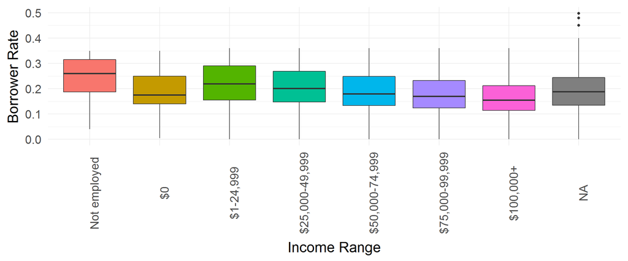

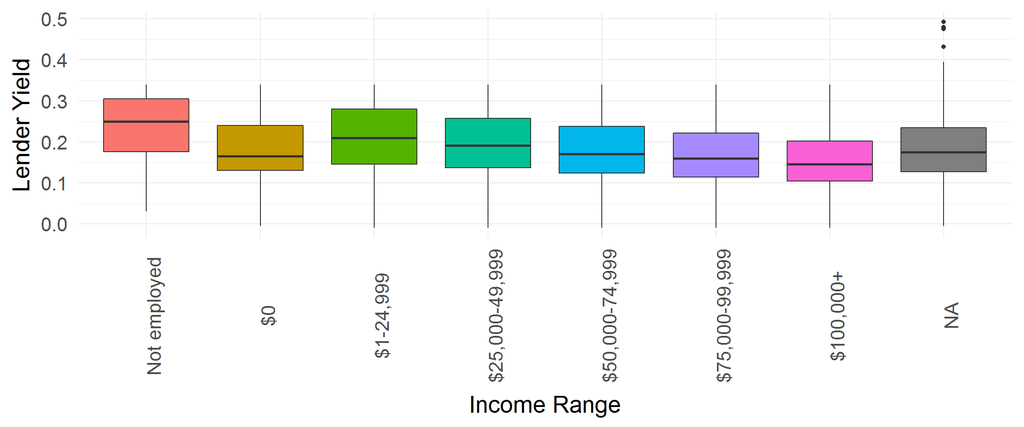

```
##   Not employed             $0      $1-24,999 $25,000-49,999 $50,000-74,999
##            806            621           7274          32192          31050
## $75,000-99,999      $100,000+           NA's
##          16916          17337           7741
```

**Does the employment status effect the borrower rate?**

Loans with an employment status of ‘not employed’ have a higher borrower rate and in turn lender yield. As such it seems that the higher risk loans have higher returns. The average borrower rate for someone employed is lower than someone who is unemployed. The average self-employed borrower rate is also slightly higher than that of their employed counterparts.

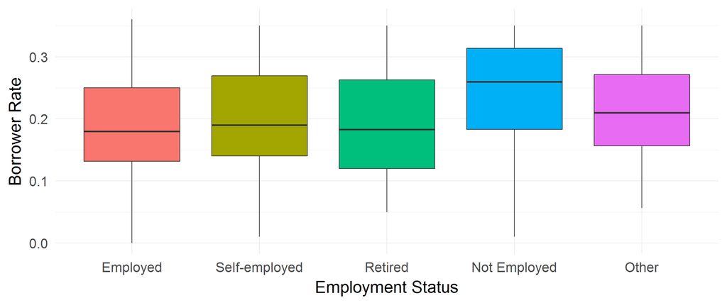

**Do riskier loans have a higher lender yield?**

Loans with a higher risk rating have a higher borrower rate and in turn a higher lender yield.

On average the borrower rate for a loan with a Prosper rating is 31.73%, while the rate for a loan with an AA rating is around 7.9%.

The average lender yield ranges from 6.91% for a loan rate AA to 30.73% for an HR rated loan.

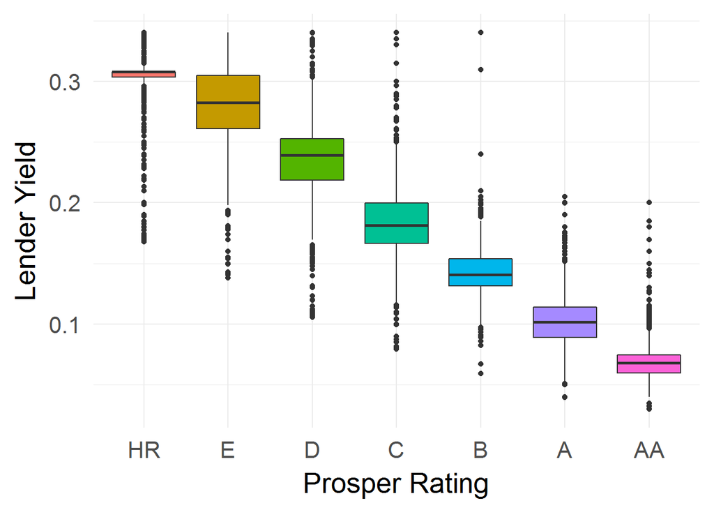

```
## loanData$ProsperRating..Alpha.: NA
## NULL
## --------------------------------------------------------
## loanData$ProsperRating..Alpha.: HR
##    Min. 1st Qu.  Median    Mean 3rd Qu.    Max.
##  0.1779  0.3134  0.3177  0.3173  0.3177  0.3600
## --------------------------------------------------------
## loanData$ProsperRating..Alpha.: E
##    Min. 1st Qu.  Median    Mean 3rd Qu.    Max.
##  0.1479  0.2712  0.2925  0.2933  0.3149  0.3600
## --------------------------------------------------------
## loanData$ProsperRating..Alpha.: D
##    Min. 1st Qu.  Median    Mean 3rd Qu.    Max.
##  0.1157  0.2287  0.2492  0.2464  0.2625  0.3500
## --------------------------------------------------------
## loanData$ProsperRating..Alpha.: C
##    Min. 1st Qu.  Median    Mean 3rd Qu.    Max.
##  0.0895  0.1765  0.1914  0.1944  0.2099  0.3500
## --------------------------------------------------------
## loanData$ProsperRating..Alpha.: B
##    Min. 1st Qu.  Median    Mean 3rd Qu.    Max.
##  0.0693  0.1414  0.1509  0.1545  0.1639  0.3500
## --------------------------------------------------------
## loanData$ProsperRating..Alpha.: A
##    Min. 1st Qu.  Median    Mean 3rd Qu.    Max.
##  0.0498  0.0990  0.1119  0.1129  0.1239  0.2150
## --------------------------------------------------------
## loanData$ProsperRating..Alpha.: AA
##    Min. 1st Qu.  Median    Mean 3rd Qu.    Max.
## 0.04000 0.06990 0.07790 0.07912 0.08450 0.21000
```

```
## loanData$ProsperRating..Alpha.: NA
## NULL
## --------------------------------------------------------
## loanData$ProsperRating..Alpha.: HR
##    Min. 1st Qu.  Median    Mean 3rd Qu.    Max.
##  0.1679  0.3034  0.3077  0.3073  0.3077  0.3400
## --------------------------------------------------------
## loanData$ProsperRating..Alpha.: E
##    Min. 1st Qu.  Median    Mean 3rd Qu.    Max.
##  0.1379  0.2612  0.2825  0.2833  0.3049  0.3400
## --------------------------------------------------------
## loanData$ProsperRating..Alpha.: D
##    Min. 1st Qu.  Median    Mean 3rd Qu.    Max.
##  0.1057  0.2187  0.2392  0.2364  0.2525  0.3400
## --------------------------------------------------------
## loanData$ProsperRating..Alpha.: C
##    Min. 1st Qu.  Median    Mean 3rd Qu.    Max.
##  0.0795  0.1665  0.1814  0.1844  0.1999  0.3400
## --------------------------------------------------------
## loanData$ProsperRating..Alpha.: B
##    Min. 1st Qu.  Median    Mean 3rd Qu.    Max.
##  0.0593  0.1314  0.1409  0.1444  0.1539  0.3400
## --------------------------------------------------------
## loanData$ProsperRating..Alpha.: A
##    Min. 1st Qu.  Median    Mean 3rd Qu.    Max.
##  0.0398  0.0890  0.1019  0.1029  0.1139  0.2050
## --------------------------------------------------------
## loanData$ProsperRating..Alpha.: AA
##    Min. 1st Qu.  Median    Mean 3rd Qu.    Max.
## 0.03000 0.05990 0.06790 0.06911 0.07450 0.20000
```

**Lender Yield by Income Range**

Unemployed borrowers followed by borrowers with an income range of $1 - $24,999 recorded the highest lender yield. We know from the previous analysis above that lenders with an income range of $1 - $24,999 have a higher Prosper rating than unemployed borrowers and borrowers earning no money and a higher Prosper score than borrowers earning no money.

This may point to an opporturnity to invest in a lower risk loan with a higher yield relative to borrowers with no recorded income.

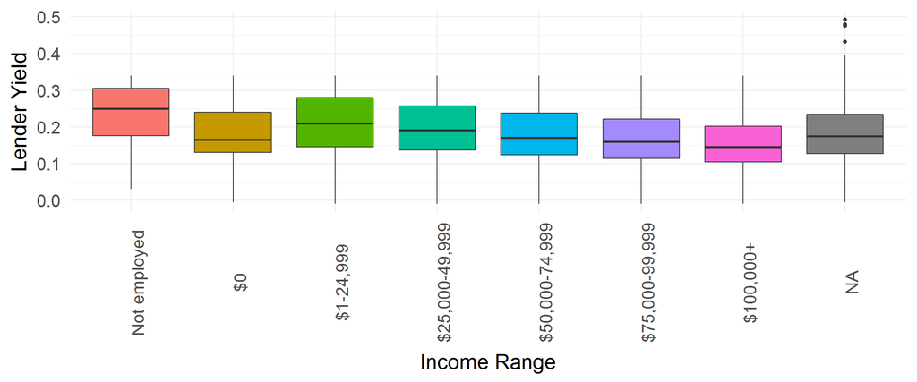

**Lender yield by Debt to Income Ratio**

Lender yield is highest for loans with a debt to income ratio of between 0.75 and 1.

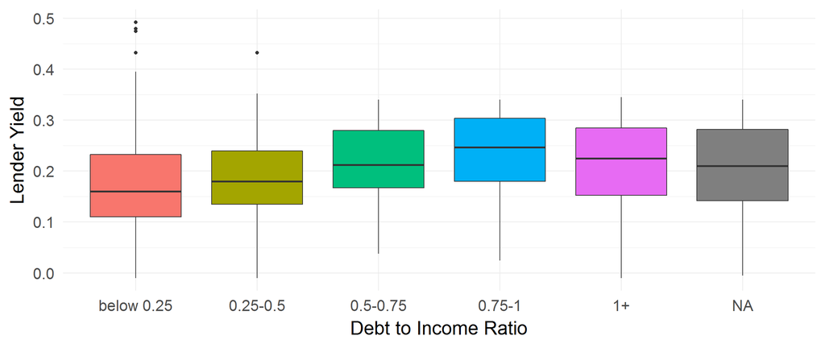

**What is the estimated loss of the loan by Prosper rating?**

The lender yield is higher for loans with a higher risk, however the estimated loss is also higher for loans with a higher risk.

We can see as the borrower rate increases the estimated principal loss on charge-offs also increases. The relationship is further demonstrated by the high correlation cooefficient between the borrower rate and the estimated principal loss variables (0.945).

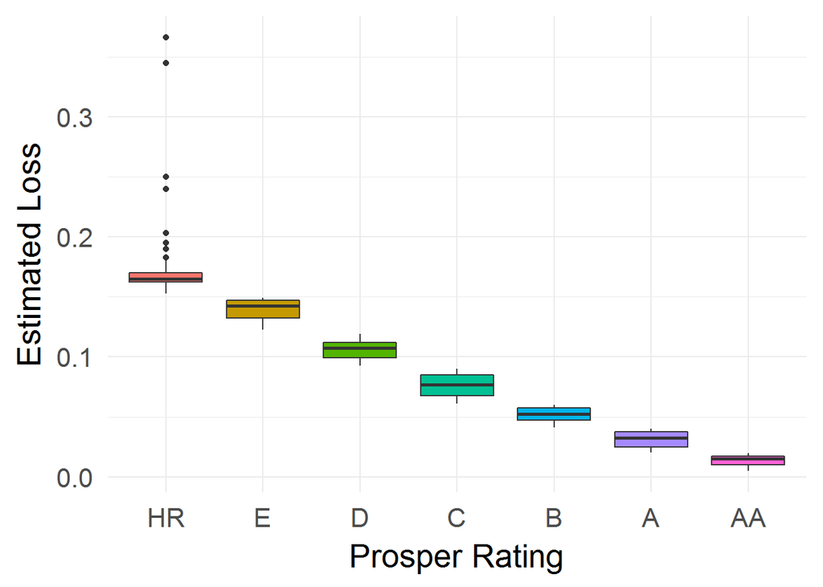

```
## loanData$ProsperRating..Alpha.: NA
## NULL
## --------------------------------------------------------
## loanData$ProsperRating..Alpha.: HR
##    Min. 1st Qu.  Median    Mean 3rd Qu.    Max.
##  0.1525  0.1625  0.1650  0.1733  0.1700  0.3660
## --------------------------------------------------------
## loanData$ProsperRating..Alpha.: E
##    Min. 1st Qu.  Median    Mean 3rd Qu.    Max.
##  0.1225  0.1325  0.1425  0.1395  0.1470  0.1490
## --------------------------------------------------------
## loanData$ProsperRating..Alpha.: D
##    Min. 1st Qu.  Median    Mean 3rd Qu.    Max.
##  0.0925  0.0990  0.1075  0.1058  0.1120  0.1190
## --------------------------------------------------------
## loanData$ProsperRating..Alpha.: C
##    Min. 1st Qu.  Median    Mean 3rd Qu.    Max.
## 0.06100 0.06740 0.07700 0.07615 0.08490 0.08990
## --------------------------------------------------------
## loanData$ProsperRating..Alpha.: B
##    Min. 1st Qu.  Median    Mean 3rd Qu.    Max.
## 0.04100 0.04740 0.05240 0.05229 0.05740 0.05990
## --------------------------------------------------------
## loanData$ProsperRating..Alpha.: A
##    Min. 1st Qu.  Median    Mean 3rd Qu.    Max.
## 0.02000 0.02490 0.03240 0.03072 0.03740 0.03990
## --------------------------------------------------------
## loanData$ProsperRating..Alpha.: AA
##    Min. 1st Qu.  Median    Mean 3rd Qu.    Max.
## 0.00490 0.01000 0.01500 0.01435 0.01740 0.01990
```

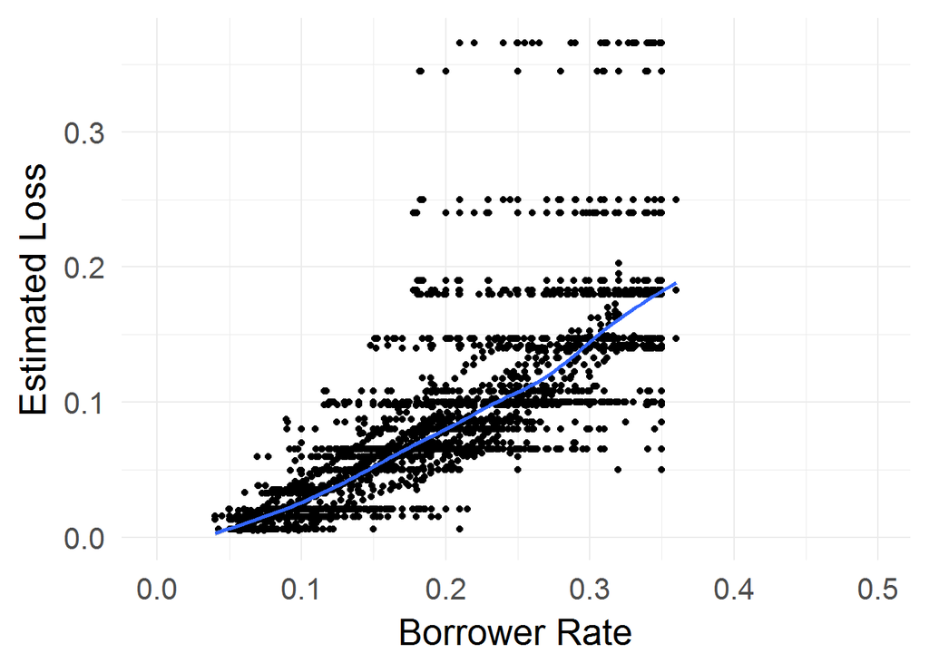

```
##
##  Pearson's product-moment correlation
##
## data:  loanData$EstimatedLoss and loanData$BorrowerRate
## t = 844.11, df = 84851, p-value < 2.2e-16
## alternative hypothesis: true correlation is not equal to 0
## 95 percent confidence interval:
##  0.9445764 0.9460085
## sample estimates:
##      cor
## 0.945297
```

**Yield Summary**

Higher risk loans come with a higher borrower rate and therefore a higher lender yield. Prosper loans follow higher risk, higher returns. Higher risk loans also come with a higher estimated loss.

Employment status, income range and the debt to income ratio all have an effect of lender yield.

There is a strong relationship bettwen the borrower rate and the estimated loss of the loan.

# Multivariate Analysis

During the bivariate analysis a few interesting relationships emerged, including between:

- loan status and Prosper rating and Prosper score;
- borrower rate and estimated loss;
- loan status and lender yield; and
- employment status and Prosper rating.

In this section I will further investigate these relationships.

**Lender Yield by Loan Category and Employment Status**

The graphs below show the proportion of defaulted and charged off loans significantly increasing with lender yield. When we look at loans by Prosper score we can see a trend in the proportion of completed loans by score. There is variation in outcome when we add employment category into the mix. Not employed borrowers recorded a higher proportion of charged off and defaulted loans, even with lower risk loans rate 8 and above.

Taking a closer look at the data we can see that loans with a lender yield of more than 0.35 are all from the year 2006. It might be that after 2006 tighter criteria was placed around borrower rate. There are also only a small number of loans with a lender yield of more than 0.35.

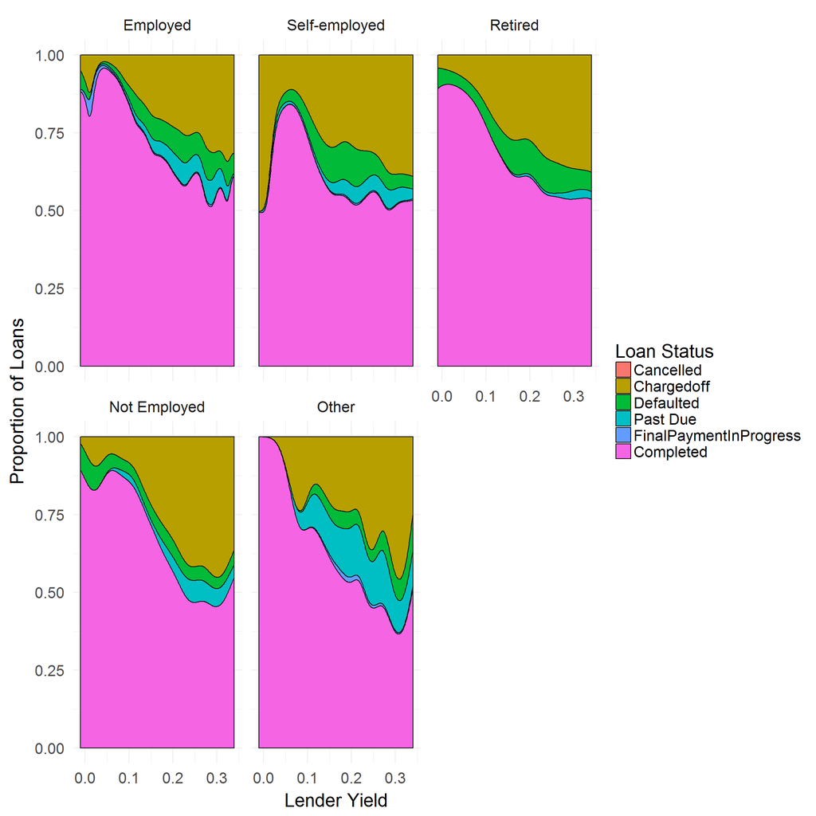

```
##                         year
## LoanCategory             2006
##   Current                   0
##   Cancelled                 0
##   Chargedoff                3
##   Defaulted                16
##   Past Due                  0
##   FinalPaymentInProgress    0
##   Completed                 5
```

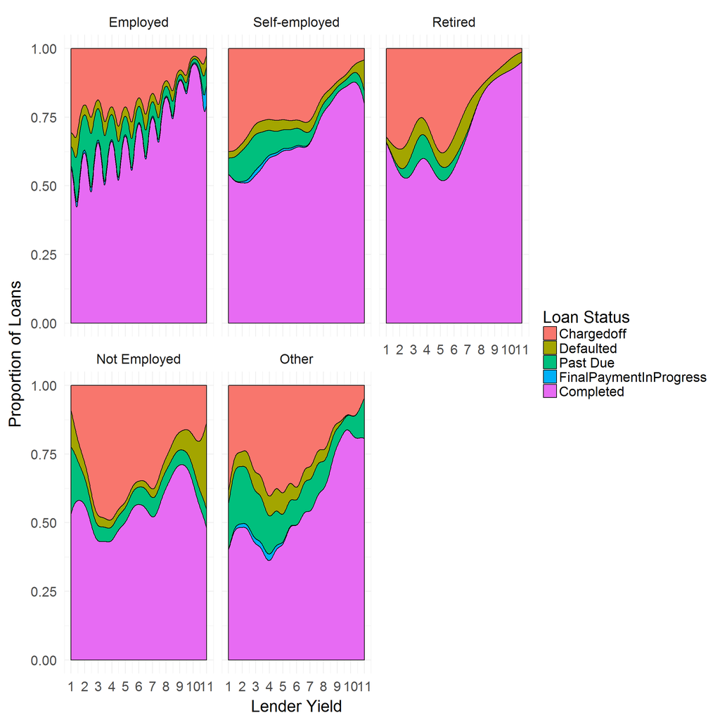

**Lender yield falls the lower the loan risk**

The average lender yield falls with loans scored as a lower risk (loans with a higher Prosper score). When we overlay employment status there is a distinct separation in the average lender yield, with higher risk employment statuses (not employed and retired) recording a higher lender yield by Prosper score.

Interestingly self-employed have a lower average lender yield than their employed and unemployed counterparts.

The overall average lender yield runs in line with employed borrowers this is due to employed borrowers accounting for the majority of loans (over 80%).

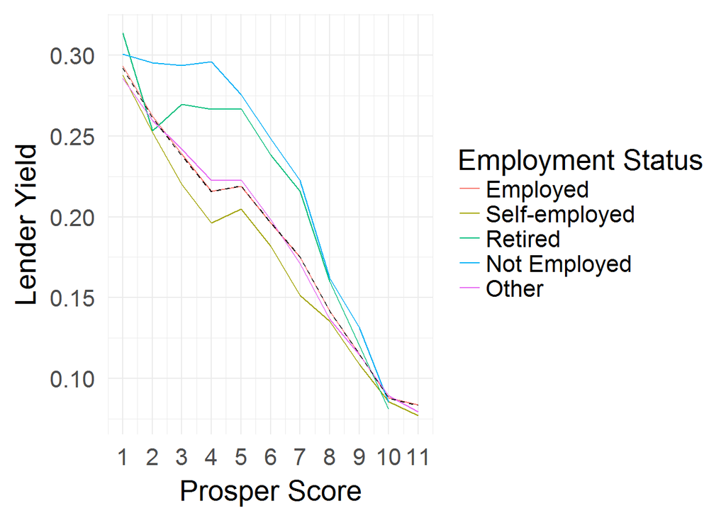

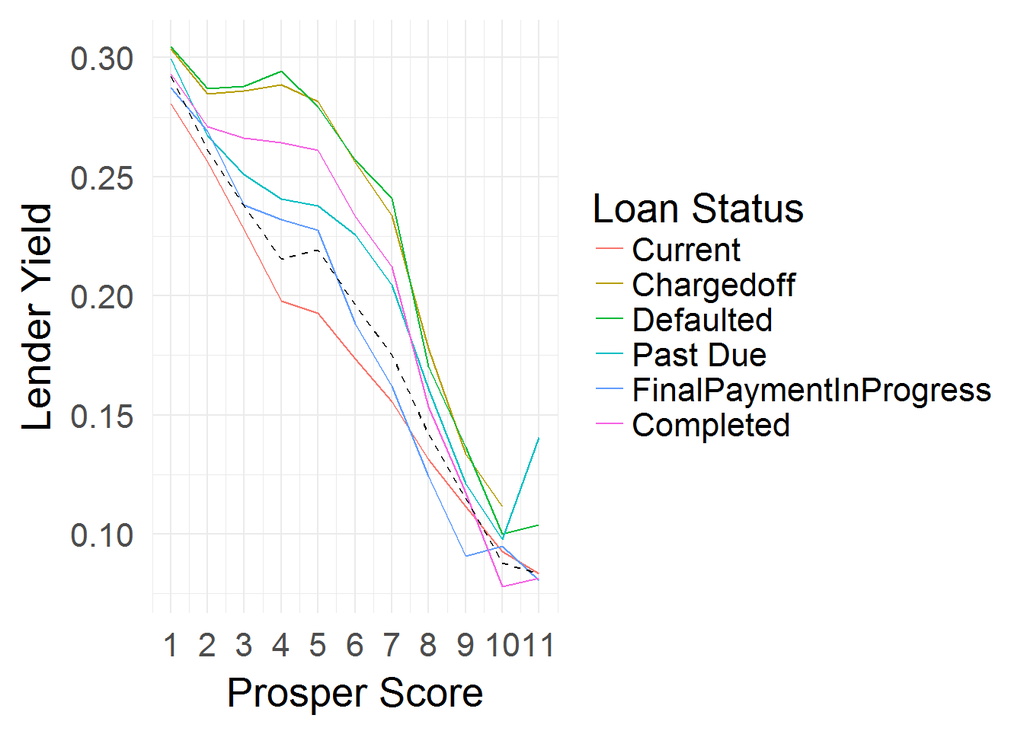

**Clear breaks in Prosper Rating**

Plotting estimated loss with borrower rate and Prosper rating shows clear bands of Prosper Ratings by estimated loss. We can also see a trend in borrower rate by Prosper Rating with lower risk loans recording a lower borrower rate.

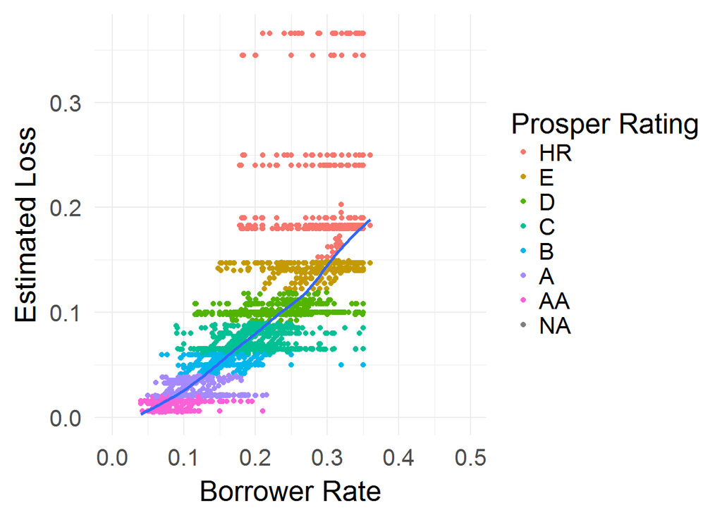

**Loans are difficult to estimate when they are high risk**

When looking at how well the estimated effective yield predicted the lender yield above, we could see that lender yield outperformed the estimated yield.

When we add the Prosper rating to colour the graph we can see that it becomes more difficult to esimate higher risk loans. That is, higher risk loans are farther away from the line representing lender yield is equal to estimated yield.

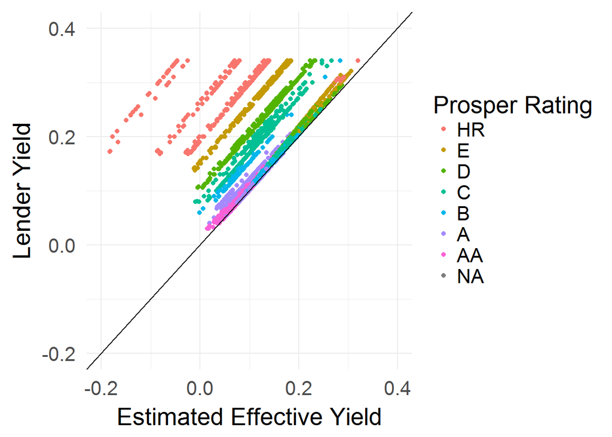

# Final Plots and Summary

### Plot One

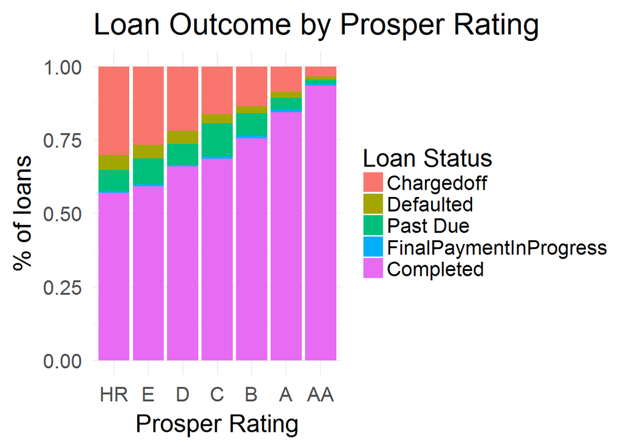

### Description One

The purpose of the Prosper rating is to allow investors to consider a loan application’s level of risk. The graph above shows the loan outcome by Prosper raing and allows the investor to gain a better understanding of the risk of the loan not completing. We can see a clear indication that loans considered to be higher risk have a higher proportion of charged off, defaulted and past due loans. Just over half of loans rated HR or E are completed. While loans rated AA have a significantly higher proportion of completed loans. This means you can invest in loans rated AA with relatively low risk. Of course, as we found out above lower risk is associated with a significantly lower average lender yield. The average lender yield for a loan rated AA is 6.91%, compared with 30.73% for an HR rated loan. There is also a relatively low proportion of AA rated loans with AA rated loans accounting for just 6% of loans.

### Plot Two

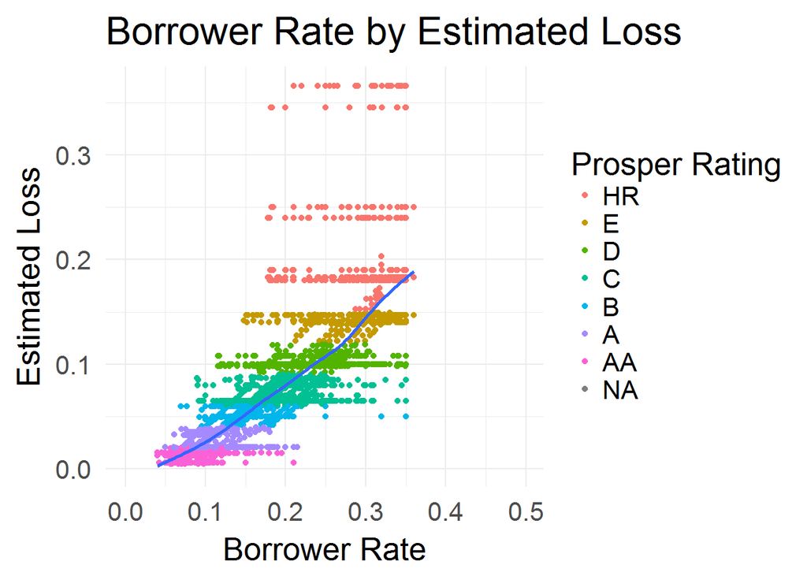

### Description Two

The plot above shows the borrower rate by the esimated loss and Propser rating. We can see the rating bands associated with the estimated loss of the loan. We can also see the borrower rate increasing with esimated loss and higher risk loans. While the Borrower Rate does increase for loans considered to be higher risk, the bands are not quite as clear. This is because there are a number of other factors that effect the borrower rate, including income range and employment status.

### Plot Three

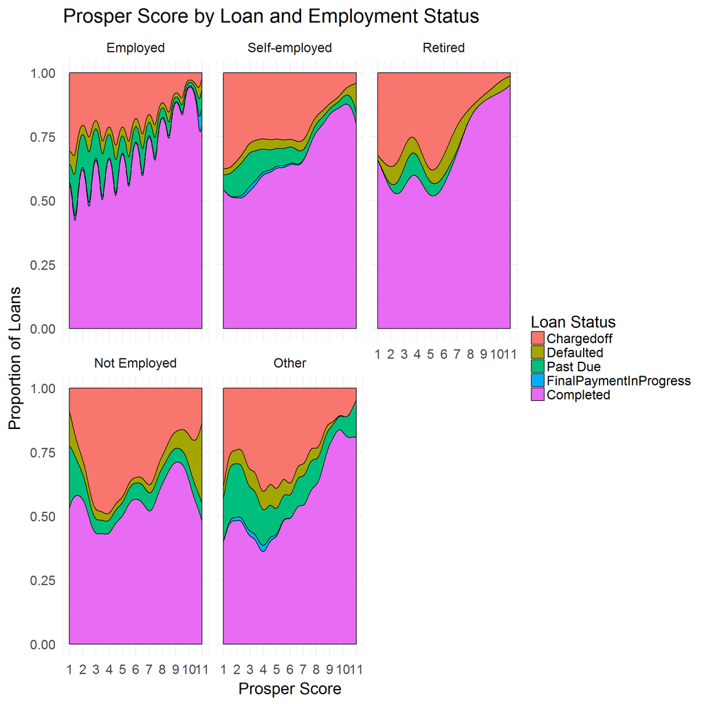

### Description Three

The final plot shows the Prosper score by employment and loan status. We can see a similar trend to plot one with the propo rtion of completed loans increasing as the risk of the loan falls. When we add the employment status variable we can see that not all employment categories are equal. Borrwers who are not employed have a lower proportion of completed loans even with lower risk loans (indicated by a higher Prosper score). Borrowers who are employed or retired appear to have the best loan outcomes with the highest proportion of completions.

# Reflection

I set out to answer two key questions, namely:

- What is the risk of investing in Prosper Loans?
- What is the potential yield of investing in Prosper Loans?

By exploring the Prosper loan data I discovered that while there are risks associated with investing in Prosper loans, the risks can be minimised by investing in loans with certain characterestics. This results in lower return, but there are other categories that can be used to gain higher yield with lower risk.

In the univariate plot section we started to look at a number of different variables with a focus on borrower characteristics and yield. The majority of Prosper loan borrowers do so to colsolidate debt. We also found out that most borrowers are employed in some capacity and earn between $25,000 and $74,999 per annum. There are clear spikes in the original loan amounts with nice round numbers (e.g. $10,000 and $15,000). It appears that borrwers may request more than they need rounding up to the nearest $5,000 increment. The Prosper rating and score are relatively normally distributed with the highest number of borrwers recording a C rating. The average lender yield is 18.27%.

We also discovered gaps in the data including periods of time where we have only partial information for the year. There were also errors in the data including unbelivably high monthly incomes. Furthermore, there are a number of variables that only have information from 2009 resulting in a high number of values categorised as not available.

In the bivariate section we delved into the variables further and found out some interesting insights includings:

- Employed borrowers recorded a higher proportion of completed loans, followed by retired borrowers;
- On average borrowers with a higher income recorded a higher Prosper score;
- Borrowers with a low stated monthly income have a higher debt to income ratio;
- Borrowers considered to be lower risk recorded a higher proportion of completed loans;
- Lender yield typically outperforms estimated effective yield; and
- Employment status, debt to income and income range all have an impact on lender yield.

In the multivariate analysis the loan characteristics were explored further with new insights revealed.

The proportion of completed loans increase when the risk of the loans decreases, but not consistently across employment categories. Unemployed borrowers recorded a higher proportion of charged off and defaulted loans even for loans considered to be lower risk.

Lender yield falls with the risk of the loan. However, there is a distinct separtion in the average lender yield when we overlay employment status. Loans become more difficult to estimate when they are higher risk.

There were a number of insights revealed into the risk and yield of Prosper loans. The next step and an interesting future project I believe is to write a model to maximise return while minimising risk. It might also be possible to use machine learning to predict if a loan will complete based on the known loan characteristics.

# References

Prosper Loan website https://www.prosper.com/

RStudio cheat sheets https://www.rstudio.com/resources/cheatsheets/

Ggplot 2 http://ggplot2.tidyverse.org/index.html

R for Data Science http://r4ds.had.co.nz/index.html